# Feature Selection Framework

RHESSysML Capstone Group

2/5/2022

# Introduction

Specific code examples in this document will be based on RHESSys model output from the Sagehen Creek Experimental Watershed in the Sierra Nevada, CA. The data set incorporates model parameter uncertainty and topographic variability under two separate climate warming scenarios: (1) Historic temperature levels, and (2) Two degrees Celsius warming. The dataset and associated metadata can be accessed [here](https://www.hydroshare.org/resource/2a31bd57b7e74c758b7857679ffbb4c5/).

response var = daily average NPP by wy and other factors

The code below is written with Net Primary Productivity (NPP) as the response variable of interest: this means that the output of this example will offer an answer to the question: What are the most important hydroecological factors that affect NPP in an ecosystem like Sagehen Creek, *and how might that relative importance change in a warming climate?*

# Setup

## renv:

To help ensure reproducibility, the packages and package versions used to build this workflow have been saved via [`renv`](https://rstudio.github.io/renv/articles/renv.html). To download any missing packages and load the correct versions, run the command `renv::restore()` in the console. Doing so will not impact your package versions outside of this R Project. It may take several minutes depending on the number of discrepancies.

```r
knitr::opts_chunk$set(echo = TRUE)

options(scipen = 999)

# Standard packages
library(tidyverse)
library(here)
library(patchwork)
library(psych)
library(kableExtra)
library(zeallot)
library(DT)
library(ggcharts)

# Machine Learning packages
library(caret)
library(spatialRF)
library(randomForest)
library(party)
library(partykit)
library(permimp)
library(rfUtilities)
library(randomForestExplainer)
library(fastshap)
```

```r
load(here::here("data", "prepared_data.RData"))
```

# Data Description

Next, we want to get a summary description of the data set. This is crucial for many reasons:

1. Shows early on in the process if any variables do not have the expected range, magnitude, class, etc.
2. Provides information on data set characteristics that are important for decisions later on in the machine learning process.

Here, we display summary statistics for the base climate scenario data.

```r
source(here::here("R", "summarize_data.R"))

summarize_data(df_wy0)
```

|  | vars | n | mean | sd | min | max | range | class |
| --- | --- | --- | --- | --- | --- | --- | --- | --- |
| response | 1 | 1620 | 0.0009 | 0.0004 | 0 | 0.0031 | 0.0031 | numeric |
| stratumID* | 2 | 1620 | 3.5 | 1.7084 | 1 | 6 | 5 | factor |
| scen* | 3 | 1620 | 3 | 1.4147 | 1 | 5 | 4 | factor |
| topo* | 4 | 1620 | 2 | 0.8167 | 1 | 3 | 2 | factor |
| lai | 5 | 1620 | 2.4499 | 0.4954 | 1.4539 | 4.0685 | 2.6146 | numeric |
| height | 6 | 1620 | 25.888 | 6.8449 | 14.075 | 41.1483 | 27.0733 | numeric |
| plantc | 7 | 1620 | 8.8459 | 2.2486 | 4.7804 | 16.0058 | 11.2254 | numeric |
| cpool | 8 | 1620 | 2.05 | 0.5271 | 1.0115 | 3.6893 | 2.6778 | numeric |
| swe | 9 | 1620 | 0.0148 | 0.0163 | 0.0004 | 0.0937 | 0.0933 | numeric |
| precip | 10 | 1620 | 0.0018 | 0.0008 | 0.0008 | 0.0039 | 0.0031 | numeric |

[output cut: 15 more lines]

```r
summarize_data(df_wy2)
```

|  | vars | n | mean | sd | min | max | range | class |
| --- | --- | --- | --- | --- | --- | --- | --- | --- |
| response | 1 | 1620 | 0.0008 | 0.0004 | -0.0003 | 0.0033 | 0.0036 | numeric |
| stratumID* | 2 | 1620 | 3.5 | 1.7084 | 1 | 6 | 5 | factor |
| scen* | 3 | 1620 | 8 | 1.4147 | 6 | 10 | 4 | factor |
| topo* | 4 | 1620 | 2 | 0.8167 | 1 | 3 | 2 | factor |
| lai | 5 | 1620 | 2.3018 | 0.4321 | 1.3939 | 3.8391 | 2.4452 | numeric |
| height | 6 | 1620 | 25.2526 | 6.4786 | 14.076 | 38.1647 | 24.0886 | numeric |
| plantc | 7 | 1620 | 8.3806 | 2.1359 | 4.3624 | 15.0073 | 10.6449 | numeric |
| cpool | 8 | 1620 | 1.9498 | 0.5308 | 0.9775 | 3.7023 | 2.7248 | numeric |
| swe | 9 | 1620 | 0.0047 | 0.0088 | 0 | 0.0674 | 0.0674 | numeric |
| precip | 10 | 1620 | 0.0018 | 0.0008 | 0.0008 | 0.0039 | 0.0031 | numeric |

[output cut: 15 more lines]

We can also look at the key study area characteristics. In this Sagehen Creek study area, there are six landscape positions where RHESSys was run.

```r
strata <- df_wy %>%
  dplyr::filter(clim == 0) %>%
  select(c(stratumID, topo, elev, aspect, slope)) %>%
  group_by(stratumID, topo) %>%
  summarize_if(is.numeric, mean) %>%
  mutate(topo = case_when(topo == "M" ~ "Mid-Slope",
                          topo == "U" ~ "Upslope",
                          topo == "R" ~ "Riparian")) %>%
  dplyr::arrange(topo) %>%
  rename("Stratum" = stratumID,
         "Topo" = topo,
         "Elevation (m)" = elev,
         "Aspect (degrees CCW from East)" = aspect,
         "Slope (degrees)" = slope)

DT::datatable(strata,
              caption = "Summary of 6 landscape positions in the Sagehen Creek study area")
```

|  | Stratum | Topo | Elevation (m) | Aspect (degrees CCW from East) | Slope (degrees) |
| --- | --- | --- | --- | --- | --- |
| 1 | 37679011 | Mid-Slope | 1937.6 | 313.30672958994 | 7.87862804928492 |
| 2 | 42316011 | Mid-Slope | 1959.067 | 85.5806432106286 | 8.4693475360648 |
| 3 | 38569011 | Riparian | 1934.8 | 287.386462712899 | 3.26923988323696 |
| 4 | 38571011 | Riparian | 1932.9 | 16.073414209923 | 1.88726568138142 |
| 5 | 36815011 | Upslope | 1956.2 | 299.82176681108 | 15.0855203795585 |
| 6 | 43583011 | Upslope | 1977.3 | 79.9073870105817 | 15.4066059279498 |

# Remove Multicollinearity

Highly correlated predictor variables are not as much a concern in machine learning when creating a predictive model. However, for this process of assessing relative predictor variable importance, multicollinear variables have biased importance (Strobl et al. 2008). Therefore, these need to be handled prior to assessing feature importance.

## Method

Below, we use Variance Inflation Factors (VIF) and Pearson Correlation Coefficients to remove variables with high multicollinearity. This is done using `auto_vif()` and `auto_cor()` from the `spatialRF` package—these two functions are used in conjunction to best minimize multicollinearity. Both functions allow the user to define an order of preference for the selection of variables, which will be discussed below. If no preference order is decided, the `auto_vif()` function orders the variables from minimum to maximum VIF, and the `auto_cor()` function orders variables by their column order.

The `auto_vif()` function works by initially starting with the variable with highest preference. Then, it iterates through the preference order list, computing the VIF for each new variable added. If the VIF of the new variable is lower than the threshold it is kept, if not the variable is removed. This process is continued until all VIF values are below the user-input threshold.

Similarly, the `auto_cor()` function works by computing a correlation matrix for all variables. Next, it computes the maximum correlation for each variable. The function then begins with the variable with lowest preference. If that variables maximum correlation coefficient is above the user-input threshold, that variable is removed. This process is continued until all correlation values are below the user-input threshold.

## Identify and Remove Correlated Variables

First, we create data frames containing only the predictor variables to assist with the next steps.

```r
# Save data frames of predictor variables for first climate scenario
df_wy0_num_preds <- df_wy0 %>%
  select(!response & where(is.numeric))

df_wy0_fpreds <- df_wy0 %>%
  select(!response & where(is.factor)) %>%
  colnames()

# Save data frames of predictor variables for second climate scenario
df_wy2_num_preds <- df_wy2 %>%
  select(!response & where(is.numeric))

df_wy2_fpreds <- df_wy2 %>%
  select(!response & where(is.factor)) %>%
  colnames()
```

Below, there are two methods for setting preference order: (1) Manually creating an ordered vector of column names, or (2) Allowing a preliminary random forest method to determine preference order based on variable importance. Note that in the preliminary random forest, highly correlated variables will not produce accurate estimates of importance. However, we assume that relative importance is reasonably accurate to support the selection between highly correlated variables. The second method is used by default.

1. Run this chunk to manually create an ordered vector of column names, starting with those of highest priority / greatest interest. The vector does not need to include the names of all predictors - only those that you would like to keep in the analysis.

```r
# Preference order can be determined manually for variables of interest:

#pref_order0 <- c("precip", "rz_storage", "trans", "evap")
#pref_order2 <- c("precip", "rz_storage", "trans", "evap")
```

2. Run this chunk to allow preliminary random forest to automatically determine preference order.

```r
# First climate scenario

# Find preliminary importance using random forest
imp0 <- train(x = df_wy0 %>% select(!response),
              y = df_wy0$response,
              method = 'rf',
              importance = TRUE,
              replace = TRUE,
              trControl = trainControl(method = "none", seed = 4326))

# Set preference order based on variable importance
pref_order0 <- varImp(imp0$finalModel, scale = FALSE) %>%
  arrange(-Overall) %>%
  rownames()

# Second climate scenario

# Find preliminary importance using random forest
imp2 <- train(x = df_wy2 %>% select(!response),
              y = df_wy2$response,
              method = 'rf',
              importance = TRUE,
              replace = TRUE,
              trControl = trainControl(method = "none", seed = 4326))

# Set preference order based on variable importance
pref_order2 <- varImp(imp2$finalModel, scale = FALSE) %>%
  arrange(-Overall) %>%
  rownames()
```

Thresholds for VIF and correlation can be set below, with default values of 5 and 0.75, respectively. Increasing the thresholds will reduce the number of variables that get removed, but it will increase the likelihood that collinearity influences the results.

```r
vif.threshold = 5
cor.threshold = 0.75
```

```r
source(here::here("R", "remove_vif.R"))
source(here::here("R", "remove_cor.R"))

# Create list of selected variables
wy0_vif <- remove_vif(df_wy0_num_preds, vif.threshold = vif.threshold, pref_order0)$selected.variables
```

```
## [auto_vif()]: Removed variables: cpool, aspect, slope, spring_tavg, fall_tavg, peak_swe, swe_precip_ratio
```

```r
wy0_cor <- remove_cor(df_wy0_num_preds, cor.threshold = cor.threshold, pref_order0)$selected.variables
```

```
## [auto_cor()]: Removed variables: slope, swe_precip_ratio, sat_deficit, cpool, peak_swe
```

```r
wy0_select_variables <- intersect(wy0_vif, wy0_cor)

wy2_vif <- remove_vif(df_wy2_num_preds, vif.threshold = vif.threshold, pref_order2)$selected.variables
```

```
## [auto_vif()]: Removed variables: cpool, swe, aspect, winter_tavg, swe_precip_ratio
```

```r
wy2_cor <- remove_cor(df_wy2_num_preds, cor.threshold = cor.threshold, pref_order2)$selected.variables
```

```
## [auto_cor()]: Removed variables: elev, sat_deficit, cpool, swe, swe_precip_ratio
```

```r
wy2_select_variables <- intersect(wy2_vif, wy2_cor)

# Combine selected variables with factors
df_wy0_preds <- c(all_of(df_wy0_fpreds), all_of(wy0_select_variables))
df_wy2_preds <- c(all_of(df_wy2_fpreds), all_of(wy2_select_variables))

# Remove numeric variables with multicollinearity
df_wy0_reduced <- df_wy0 %>%
  select(c(response, all_of(df_wy0_preds)))

df_wy2_reduced <- df_wy2 %>%
  select(c(response, all_of(df_wy2_preds)))
```

## Summary of Removed Variables

The next step is intended to elucidate the previous multicollinearity reduction process via figures showing which variables were selected and removed, and why. This information can be used to determine whether the auto-generated preference order based on preliminary importance performed satisfactorily, or whether the preference order should be set manually. If, for example, a variable of particular interest was removed, the `manual_preference_order` code chunk above can be used to create a preference order containing the desired variable.

```r
source(here::here("R", "summarize_var_removal.R"))
source(here::here("R", "plot_removed_cor.R"))
```

The following functions output summary tables and plots showing variable selection status and the values of VIF, correlation, and importance which led to those selections.

### Climate Scenario 0

#### Variable Removal Summary Table

```r
summarize_var_removal(df_wy0_num_preds, table = TRUE)
```

|  | Variable | Selected Status | Preliminary importance rank | VIF |
| --- | --- | --- | --- | --- |
| 1 | lai | selected | 17 | 3.846 |
| 2 | height | selected | 20 | 1.452 |
| 3 | plantc | selected | 6 | 20.924 |
| 4 | cpool | removed | 10 | 19.836 |
| 5 | swe | selected | 7 | 13.728 |
| 6 | precip | selected | 1 | 8.279 |
| 7 | trans | selected | 5 | 5.648 |
| 8 | evap | selected | 4 | 2.96 |
| 9 | sat_deficit | removed | 12 | 5.882 |
| 10 | rz_storage | selected | 2 | 4.712 |

[output cut: 11 more lines]

#### Cor Summary Plot

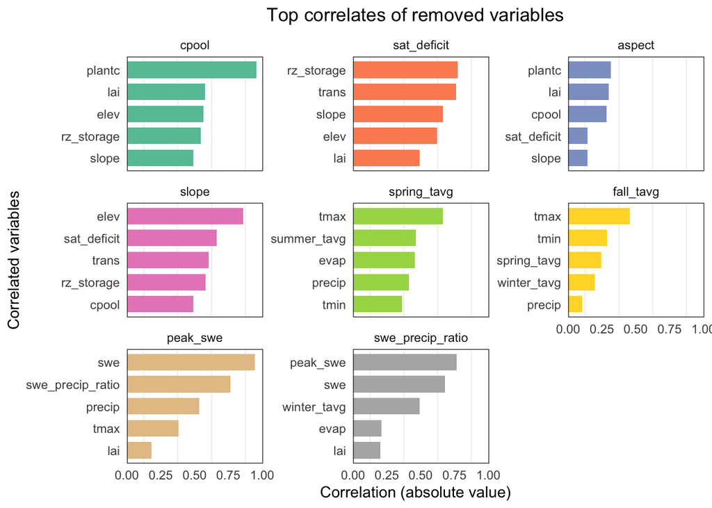

```r
# this was originally plot_cor() but that function didn't exist so I changed it... need library ggcharts above
plot_removed_cor(wy0_select_variables, df_wy0_num_preds)
```

### Climate Scenario 2

#### Variable Removal Summary Table

```r
summarize_var_removal(df_wy2_num_preds, table = TRUE)
```

|  | Variable | Selected Status | Preliminary importance rank | VIF |
| --- | --- | --- | --- | --- |
| 1 | lai | selected | 18 | 2.962 |
| 2 | height | selected | 19 | 1.467 |
| 3 | plantc | selected | 9 | 12.949 |
| 4 | cpool | removed | 14 | 12.286 |
| 5 | swe | removed | 10 | 11.076 |
| 6 | precip | selected | 1 | 6.116 |
| 7 | trans | selected | 4 | 5.661 |
| 8 | evap | selected | 5 | 2.683 |
| 9 | sat_deficit | removed | 16 | 6.255 |
| 10 | rz_storage | selected | 2 | 4.967 |

[output cut: 11 more lines]

#### Cor Summary Plot

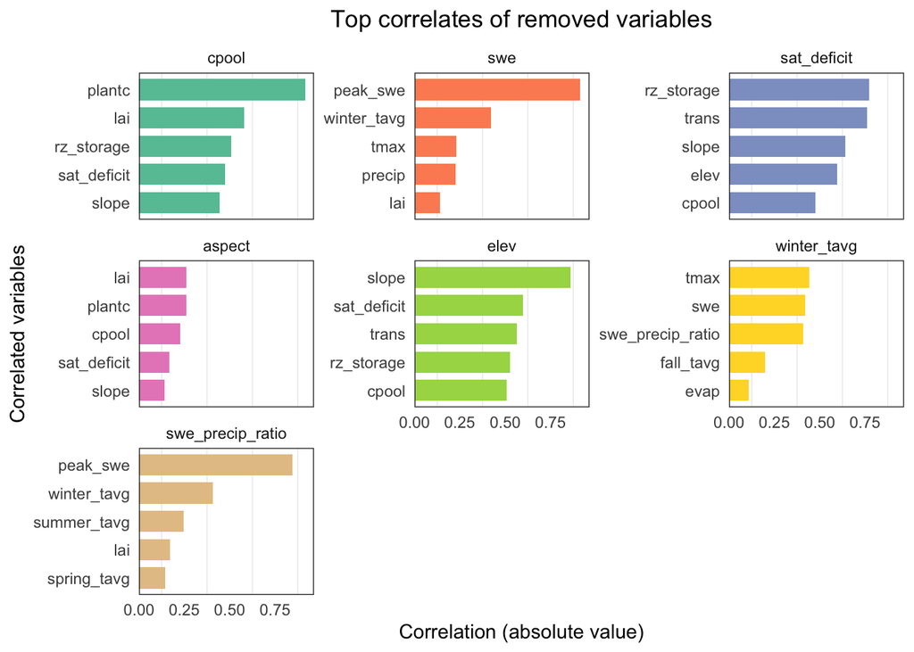

```r
plot_removed_cor(wy2_select_variables, df_wy2_num_preds)
```

# Feature Importance

With multicollinearity reduced, the importance of predictor variables can be estimated using Random Forest and partial permutation importance. In this framework, we use Random Forest because it has been shown to be an effective tool in assessing feature importance in numerous applications including ecological analysis (Cutler et al. 2007; Prasad et al. 2006). Additionally, Random Forest requires relatively less hyper-parameter tuning than other common techniques.

### Hyper-Parameter Tuning

An essential part of building a machine learning model is tuning hyper-parameters. This entails altering parameters which the user has control over in order to attain an optimal model accuracy. The following tuning process has been automated and only involves `mtry`—the primary parameter that requires adjustment in a Random Forest.

The `mtry` parameter determines the number of variables randomly sampled as candidates at each split. The default value for regression is p/3, where p is the number of predictor variables.

The function below creates a vector of accuracy results of random forests using different values for `mtry`.

```r
df_wy0_reduced <- as.data.frame(df_wy0_reduced)
df_wy2_reduced <- as.data.frame(df_wy2_reduced)
```

Next, we run the function for both climate scenario data sets and visualize the results. Model error here is assessed using out-of-bag (OOB) observations in the data, which refers to observations that were not sampled during bootstrapping for the particular Random Forest being assessed. In other words OOB data were not used to train the model and can be used to test accuracy without the risk of bias incurred from model over-fitting. The best `mtry value` in the plots below will be represented by the lowest `OOB Error`.

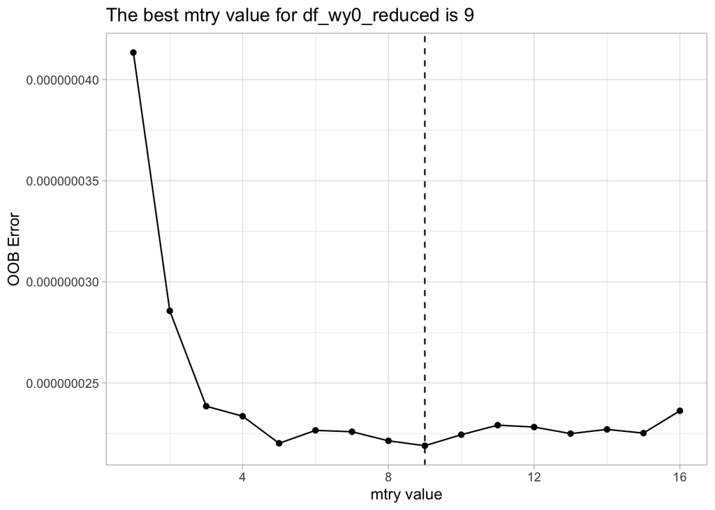

```r
source(here::here("R", "tune_rf_model.R"))

set.seed(4326)

mtry0 <- tune_rf_model(df_wy0_reduced)
bestmtry0 <- match(min(mtry0), mtry0)
ggplot(data = as.data.frame(mtry0), aes(x = 1:length(mtry0), y = mtry0)) +
  geom_vline(xintercept = bestmtry0, linetype = "dashed") +
  geom_point() +
  geom_line() +
  theme_light() +
  labs(x = "mtry value",
       y = "OOB Error",
       title = paste0("The best mtry value for ", deparse(substitute(df_wy0_reduced)), " is ", bestmtry0))
```

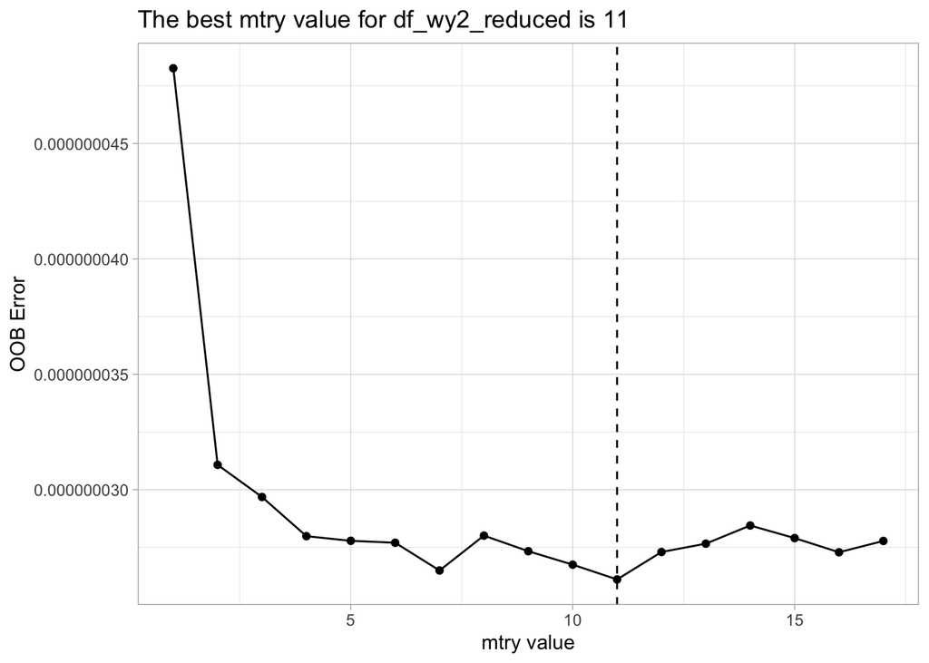

```r
set.seed(4326)

mtry2 <- tune_rf_model(df_wy2_reduced)
bestmtry2 <- match(min(mtry2), mtry2)
ggplot(data = as.data.frame(mtry2), aes(x = 1:length(mtry2), y = mtry2)) +
  geom_vline(xintercept = bestmtry2, linetype = "dashed") +
  geom_point() +
  geom_line() +
  theme_light() +
  labs(x = "mtry value",
       y = "OOB Error",
       title = paste0("The best mtry value for ", deparse(substitute(df_wy2_reduced)), " is ", bestmtry2))
```

### Random Forest Models

```r
rf_wy0 <- train(x = df_wy0_reduced %>% select(!response),
                y = df_wy0_reduced$response,
                method = 'rf',
                .mtry = bestmtry0,
                ntree = 500,
                importance = TRUE,
                replace = TRUE,
                keep.forest = TRUE,  # necessary for permimp
                keep.inbag = TRUE,  # necessary for permimp
                trControl = trainControl(method = "none", seed = 4326)) # to use 10-fold cross validation, method = "cv", number = 10

rf_wy2 <- train(x = df_wy2_reduced %>% select(!response),
                y = df_wy2_reduced$response,
                method = 'rf',
                .mtry = bestmtry2,
                ntree = 500,
                importance = TRUE,
                replace = TRUE,
                keep.forest = TRUE,  # necessary for permimp
                keep.inbag = TRUE,  # necessary for permimp
                trControl = trainControl(method = "none", seed = 4326)) # to use 10-fold cross validation, method = "cv", number = 10
```

```r
# save models for the Shiny app
saveRDS(rf_wy0, here::here("data", "rf_wy0.RDS"))
saveRDS(rf_wy2, here::here("data", "rf_wy2.RDS"))
```

Assessing feature importance is a complex task with many possible approaches. Tree based models like random forest offer convenient “split-improvement” measures, like mean increase in purity and minimum depth, which are intrinsically derived during model construction. However, these have been shown to be biased towards variables with many categories or large value ranges (Strobl et al. 2007). Despite some of their shortcomings, these importance measures can provide insights are further explored at the end of this document.

As the primary measure of importance we instead use partial permutation importance via the `varImp` function. Permutation importance has been tested and determined to be the most unbiased importance metric for data with a mix of categorical and continuous variables with a variety of classes and ranges, respectively. This is calculated in the following steps…

1. Assess prediction accuracy (mean squared error) of the model on the out-of-bag data.
2. Permute the values of a given variable.
3. Feed the dataset with the permuted values into the Random Forest and reassess model accuracy.
4. Importance of the permuted variable is deemed to be the mean loss in accuracy when its values were permuted.

```r
imp_wy0 <- varImp(rf_wy0$finalModel, scale = FALSE) %>%
  rownames_to_column("Variable") %>%
  mutate(Rank = rank(-Overall))

imp_wy2 <- varImp(rf_wy2$finalModel, scale = FALSE) %>%
  rownames_to_column("Variable") %>%
  mutate(Rank = rank(-Overall))
```

Save the above importance dataframes to be used in the Shiny App.

```r
# This will export the importance rank datasets as csv files to be used in the shiny app. However, once again we will leave this commented out so that it doesn't export new csv files every time the workflow runs.

saveRDS(imp_wy0, file = here::here("shiny", "aggregated_datasets", "imp_wy0.RDS"))
saveRDS(imp_wy2, file = here::here("shiny", "aggregated_datasets", "imp_wy2.RDS"))
```

# Model Evaluation

The following section provides visualizations and statistics to evaluate the random forest performance.

Calling the random forest shows a summary of the results, including percent variance explained.

```r
rf_wy0_fit <- round(tail(rf_wy0$finalModel$rsq, 1)*100, 2)

rf_wy0$finalModel
```

```
##
## Call:
##  randomForest(x = x, y = y, ntree = 500, mtry = min(param$mtry,      ncol(x)), replace = TRUE, importance = TRUE, keep.forest = TRUE,      keep.inbag = TRUE, .mtry = ..1)
##                Type of random forest: regression
##                      Number of trees: 500
## No. of variables tried at each split: 5
##
##           Mean of squared residuals: 0.0000000203804
##                     % Var explained: 89.41
```

The model for the base climate scenario explained 89.41% of variance in NPP.

```r
rf_wy2_fit <- round(tail(rf_wy2$finalModel$rsq, 1)*100, 2)

rf_wy2$finalModel
```

```
##
## Call:
##  randomForest(x = x, y = y, ntree = 500, mtry = min(param$mtry,      ncol(x)), replace = TRUE, importance = TRUE, keep.forest = TRUE,      keep.inbag = TRUE, .mtry = ..1)
##                Type of random forest: regression
##                      Number of trees: 500
## No. of variables tried at each split: 5
##
##           Mean of squared residuals: 0.00000002548118
##                     % Var explained: 86.83
```

The model for the +2 degree Celsius climate scenario explained 86.83% of variance in NPP.

# Visualize Results

Now, we can visualize the results of the Random Forest feature selection.

The following table shows the relative importance of predictor variables between the two climate scenarios.

```r
source(here::here("R", "df_imp_table.R"))

df_imp_table(imp_wy0, imp_wy2)
```

Difference in variable importance for the two climate scenarios

| Variable | Rank (0) | Rank (2) | Diff |
| --- | --- | --- | --- |
| precip | 1 | 1 | 0 |
| rz_storage | 2 | 2 | 0 |
| evap | 3 | 5 | -2 |
| tmin | 4 | 6 | -2 |
| trans | 5 | 4 | 1 |
| plantc | 6 | 9 | -3 |
| swe | 7 | NA | NA |
| summer_tavg | 8 | 8 | 0 |
| winter_tavg | 9 | NA | NA |
| tmax | 10 | 10 | 0 |
| scen | 11 | 11 | 0 |
| stratumID | 12 | 15 | -3 |
| lai | 13 | 14 | -1 |
| elev | 14 | NA | NA |
| height | 15 | 13 | 2 |
| topo | 16 | 17 | -1 |
| peak_swe | NA | 3 | NA |
| spring_tavg | NA | 7 | NA |
| fall_tavg | NA | 12 | NA |
| slope | NA | 16 | NA |

This same information is plotted below. The variable importance plots also reveal relative magnitude of importance between variables.

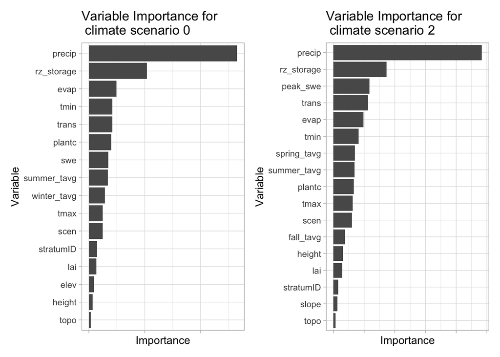

```r
source(here::here("R", "plot_imp.R"))

wy0_plot <- plot_imp(imp_wy0)
wy2_plot <- plot_imp(imp_wy2)

wy0_plot + wy2_plot
```

## Previewing relationships between important predictors and NPP

The variable importance values derived from our Random Forest model allow us to investigate interesting relationships and interactions between the response term and important predictors. Below, we investigate how NPP’s relationship with the most important predictor is impacted by changes in other predictors in the model.

```r
source(here::here("R", "get_important_predictors.R"))

# assigning first and second most important variables to objects
pred1_clim0 <- get_important_predictors(imp_wy0, 1)
pred2_clim0 <- get_important_predictors(imp_wy0, 2)
pred1_clim2 <- get_important_predictors(imp_wy2, 1)
pred2_clim2 <- get_important_predictors(imp_wy2, 2)

source(here::here("R", "create_binned_df.R"))

df0_pred_binned <- create_binned_df(df_wy0)
df2_pred_binned <- create_binned_df(df_wy2)
```

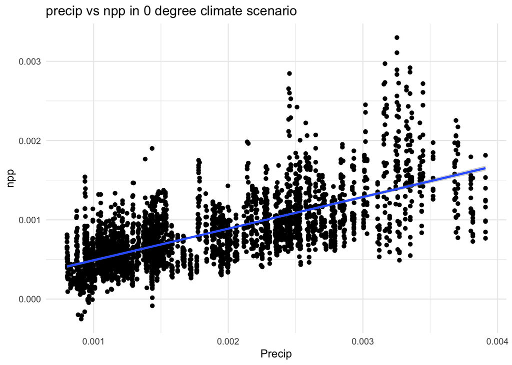

```r
ggplot(df0_pred_binned, aes(x = pred1, y = .data[["response"]])) +
  geom_point() +
  geom_smooth(method = "lm") +
  labs(x = str_to_title(pred1_clim0), y = response_var,
       title = paste(pred1_clim0, "vs", response_var,
                     "in 0 degree climate scenario")) +
  theme_minimal()
```

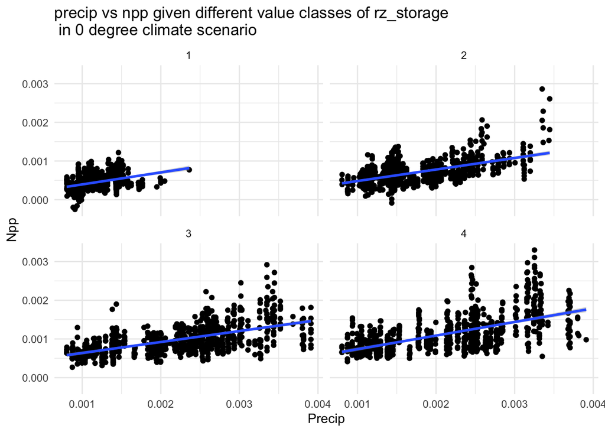

```r
source(here::here("R", "create_binned_plot.R"))

create_binned_plot(df0_pred_binned)
```

[figure not shown]

```r
create_binned_plot(df2_pred_binned)
```

Variable interactions can be investigated in many ways. The bivariate partial dependence plot below provides a graphical depiction of the marginal effect of two variables on predicted NPP from the random forest model.

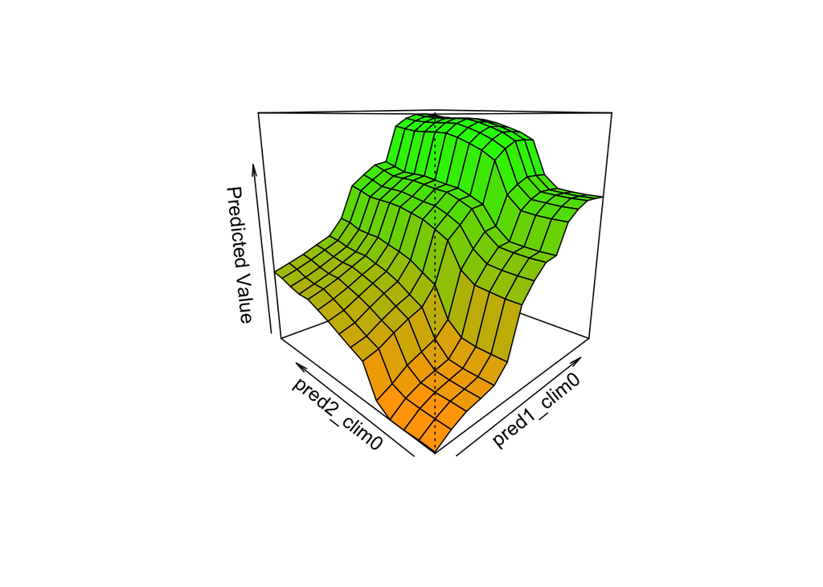

```r
bivariate.partialDependence(x = rf_wy0$finalModel,
                            pred.data = df_wy0_reduced[-1],
                            v1 = pred1_clim0,
                            v2 = pred2_clim0,
                            grid.size = 15,
                            col.ramp = c("orange", "green"),
                            ncols = 20)
```

Running this plot for both data sets can demonstrate how variable interactions shift given different climate scenarios.

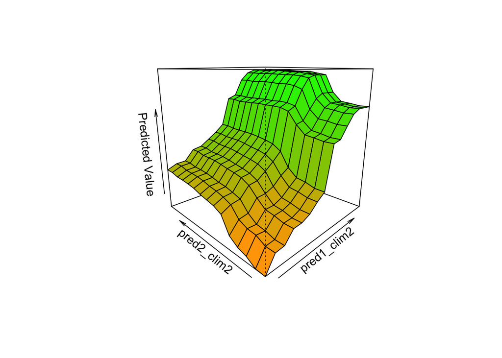

```r
bivariate.partialDependence(x = rf_wy2$finalModel,
                            pred.data = df_wy2_reduced[-1],
                            v1 = pred1_clim2,
                            v2 = pred2_clim2,
                            grid.size = 15,
                            col.ramp = c("orange", "green"),
                            ncols = 20)
```

Variable interactions between two predictors and the corresponding NPP predictions from the random forest model can be displayed as a grid of values.

```r
# plot_predict_interaction(rf_wy0$finalModel, df_wy0_reduced,
#                          "rz_storage", "precip",
#                          grid = 50) # smaller grid values reveal more general relationships
```

## Comparison with other measures of importance

The capstone team chose to use permutation importance above as our main representation of importance. However there are other potential methods of determining relative importance from random forest models that are demonstrated below. Note that the interpretation of these measures, as discussed in the original justification of using permutation importance, is limited due to characteristics of RHESSys data. Namely, the presence of both categorical and continuous variables, differing number of classes in categorical variables, differing scales of numeric variables, and potential remaining multicollinearity all have greater potential to skew the results of the methods below.

The plot below presents the top 10 variables using % mean decrease in accuracy (%IncMSE) and mean decrease in node impurity (IncNodePurity). %IncMSE is computed from permuting the out-of-bag data, while IncNodePurity is the mean total decrease in node impurities from splitting on the given variable, as measured by the residual sum of squares.

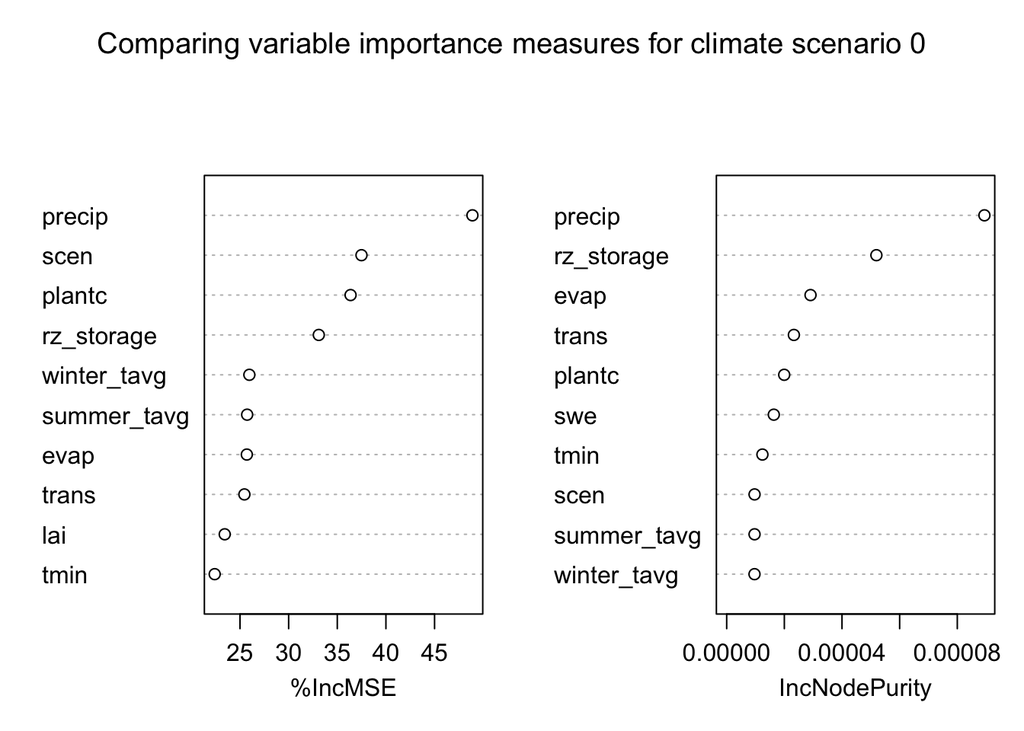

```r
varImpPlot(rf_wy0$finalModel, n.var = 10, main = "Comparing variable importance measures for climate scenario 0")
```

The plot below visualizes the distribution of minimum depth from the random forest model. Low values, such as for precipitation below, indicate that many observations are divided into groups based on that variable.

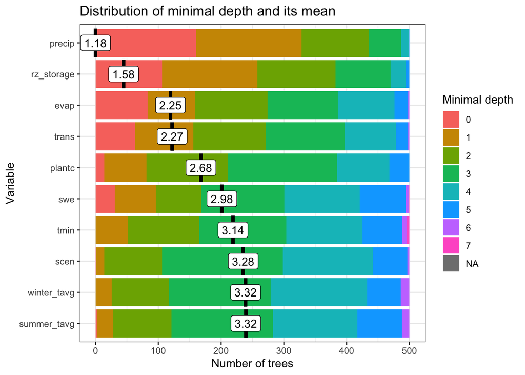

```r
min_depth_frame <- min_depth_distribution(rf_wy0$finalModel)

plot_min_depth_distribution(min_depth_frame,
                            mean_sample = "relevant_trees")
```

Lastly, SHapley Additive exPlanations (SHAP) values interpret the marginal contributions of individual features. This allows visualization of the direction of the relationships between predictors and the response variable.

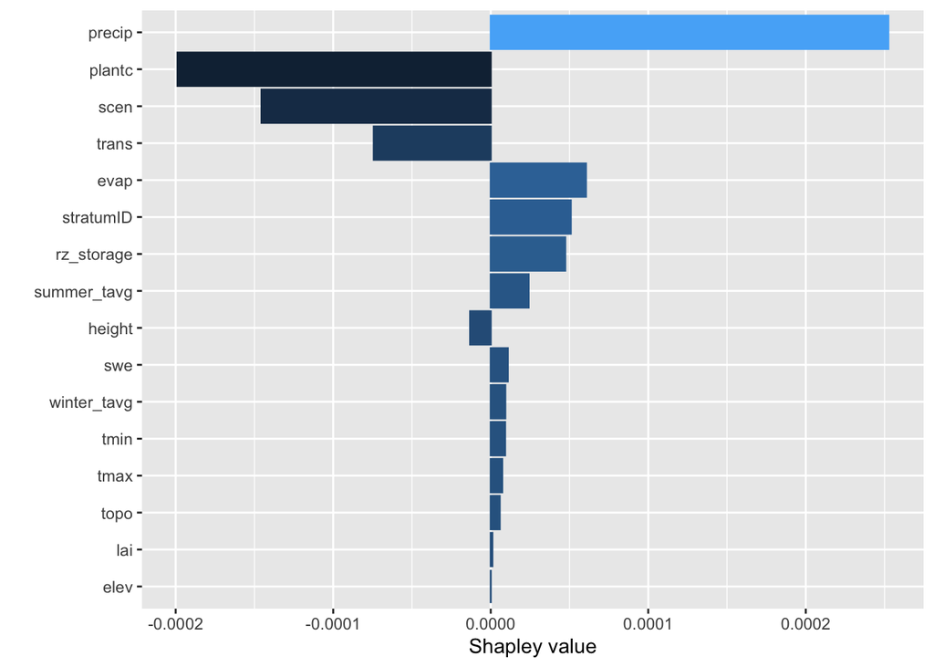

```r
explain0 <- fastshap::explain(object = rf_wy0$finalModel,
                    X = subset(df_wy0_reduced, select = -response),
                    pred_wrapper = predict)

autoplot(explain0, type = "contribution", feature = "response")
```

# References

Cutler, D. Richard, Thomas C. Edwards, Karen H. Beard, Adele Cutler, Kyle T. Hess, Jacob Gibson, and Joshua J. Lawler. 2007. “Random Forests for Classification in Ecology.” *Ecology* 88 (11): 2783–92. https://doi.org/10.1890/07-0539.1.

Debeer, Dries, and Carolin Strobl. 2020. “Conditional Permutation Importance Revisited.” *BMC Bioinformatics* 21 (1): 307. https://doi.org/10.1186/s12859-020-03622-2.

Prasad, Anantha M., Louis R. Iverson, and Andy Liaw. 2006. “Newer Classification and Regression Tree Techniques: Bagging and Random Forests for Ecological Prediction.” *Ecosystems* 9 (2): 181–99. https://doi.org/10.1007/s10021-005-0054-1.

Strobl, Carolin, Anne-Laure Boulesteix, Achim Zeileis, and Torsten Hothorn. 2007. “Bias in Random Forest Variable Importance Measures: Illustrations, Sources and a Solution.” *BMC Bioinformatics* 8 (1): 25. https://doi.org/10.1186/1471-2105-8-25.

Strobl, Carolin, Anne-Laure Boulesteix, Thomas Kneib, Thomas Augustin, and Achim Zeileis. 2008. “Conditional Variable Importance for Random Forests.” *BMC Bioinformatics* 9 (1): 307. https://doi.org/10.1186/1471-2105-9-307.